# US Brewery Analysis

Tanvi Arora, Anne Francomano, Anjli Solsi, Rebecca Holsapple

June 24, 2018

# Introduction

Steeped in a tradition of innovation for the past 150 years, the family-owned De Halve Maan brewery in Bruges, Belgium, is keen to expand its presence into the U.S. market. Our team is assisting management with determining if there is a particular U.S. location (e.g. state) that would present an opportunity.

Here, in phase one of the investigation, we look at two key beer product line characteristics of interest: the Alcohol Content by Volume (ABV) and the International Bittering Units scale (IBU) rating. Note that IBU metric is equivalent to the European Measurement of Bitterness (EBU). The difference between EBU and IBU is negligible (See Alworth, Jeff (2015) The Beer Bible: The Essential Beer Lover’s Guide. New York, NY: Workman Publishing, page 8. https://www.amazon.com/Beer-Bible-Jeff-Alworth/dp/0761168117). Therefore, the EBU ratings of De Halve Maan’s products that have been provided by our client contact, were compared directly to the IBU ratings of the US breweries’ beers.

```r
knitr::opts_chunk$set(echo = TRUE, cache = FALSE , warning=FALSE)
# ensure below packages are installed in R
library(knitr)
```

```r
library(ggplot2)
library(scales)
# read external R source files
read_chunk('Code/load_dataset.R')
read_chunk('Code/Column_NAs.R')
read_chunk('Code/Merge_Beers_Breweries.R')
read_chunk('Code/BreweryCountByState.R')
read_chunk('Code/SummaryStatisticsForABV.R')
read_chunk('Code/Compare_ABV_IBU.R')
read_chunk('Code/Max_ABV_IBU_State.R')
read_chunk('Code/Scatterplot_ABV_IBU.R')
```

# Data Source

The two data sets utilized in the analyses were obtained from iBeverage, Inc., in NY. One data set listed 558 breweries encompassing all 51 US states. The second data set reflects all 2410 beers brewed by each US brewery in the first data set. In order to perform a portion of the analysis it was necessary to merge the two data sets.

```r
beer <- read.csv('Data/Beers.csv', header=TRUE)

##structure of beer dataset

str(beer)
```

```
## 'data.frame':    2410 obs. of  7 variables:
##  $ Name      : Factor w/ 2305 levels "#001 Golden Amber Lager",..: 1638 577 1705 1842 1819 268 1160 758 1093 486 ...
##  $ Beer_ID   : int  1436 2265 2264 2263 2262 2261 2260 2259 2258 2131 ...
##  $ ABV       : num  0.05 0.066 0.071 0.09 0.075 0.077 0.045 0.065 0.055 0.086 ...
##  $ IBU       : int  NA NA NA NA NA NA NA NA NA NA ...
##  $ Brewery_id: int  409 178 178 178 178 178 178 178 178 178 ...
##  $ Style     : Factor w/ 100 levels "","Abbey Single Ale",..: 19 18 16 12 16 80 18 22 18 12 ...
##  $ Ounces    : num  12 12 12 12 12 12 12 12 12 12 ...
```

Original Beer dataset contains following information -

Name: Name of the beer.  
Beer_ID: Unique identifier of the beer.  
ABV: Alcohol by volume of the beer.  
IBU: International Bitterness Units of the beer.  
Brewery_id: Brewery id associated with the beer.  
Style: Style of the beer.  
Ounces: Ounces of beer.

```r
## load Dataset - Brewries.csv

breweries <- read.csv('Data/Breweries.csv', header=TRUE)

##structure of breweries dataset

str(breweries)
```

```
## 'data.frame':    558 obs. of  4 variables:
##  $ Brew_ID: int  1 2 3 4 5 6 7 8 9 10 ...
##  $ Name   : Factor w/ 551 levels "10 Barrel Brewing Company",..: 355 12 266 319 201 136 227 477 59 491 ...
##  $ City   : Factor w/ 384 levels "Abingdon","Abita Springs",..: 228 200 122 299 300 62 91 48 152 136 ...
##  $ State  : Factor w/ 51 levels " AK"," AL"," AR",..: 24 18 20 5 5 41 6 23 23 23 ...
```

Original Breweries dataset contains following information -

Brew_ID: Unique identifier of the brewery.  
Name: Name of the brewery.  
City: City where the brewery is located.  
State: U.S. State where the brewery is located.

```r
#create state information dataset using available R dataset
state.info <- cbind.data.frame(state.abb, state.name, state.region)
names(state.info) <- c("State", "State_Name", "State_Region")

#validate state.info dataset created correctly
str(state.info)
```

```
## 'data.frame':    50 obs. of  3 variables:
##  $ State       : Factor w/ 50 levels "AK","AL","AR",..: 2 1 4 3 5 6 7 8 9 10 ...
##  $ State_Name  : Factor w/ 50 levels "Alabama","Alaska",..: 1 2 3 4 5 6 7 8 9 10 ...
##  $ State_Region: Factor w/ 4 levels "Northeast","South",..: 2 4 4 2 4 4 1 2 2 2 ...
```

State dataset is created from available R datasets -

State : dataset state.abb , is the 2 character ISO state code  
State_Name : dataset state.name , is the full name of the state  
State_Region : dataset state.region , is the region the state belongs to

# Data Description

```r
#change column names
colnames(beer) <- c("Beer_Name", "Beer_ID", "ABV", "IBU", "Brewery_ID", "Style", "Ounces")
colnames(breweries) <- c("Brewery_ID", "Brewery_Name", "Brewery_City", "Brewery_State")
names(beer)
```

```
## [1] "Beer_Name"  "Beer_ID"    "ABV"        "IBU"        "Brewery_ID"
## [6] "Style"      "Ounces"
```

```r
names(breweries)
```

```
## [1] "Brewery_ID"    "Brewery_Name"  "Brewery_City"  "Brewery_State"
```

```r
#report number of NAs in beer and breweries dataset
colSums(is.na(beer))
```

```
##  Beer_Name    Beer_ID        ABV        IBU Brewery_ID      Style
##          0          0         62       1005          0          0
##     Ounces
##          0
```

```r
colSums(is.na(breweries))
```

```
##    Brewery_ID  Brewery_Name  Brewery_City Brewery_State
##             0             0             0             0
```

```r
#identify the records with blank values for the variable Style in the beer dataset
#beer[which(beer$Style==''),]
length(which(beer$Style==''))
```

```
## [1] 5
```

```r
#merge beer dataset and breweries dataset
##beer.breweries <- merge(beer, breweries, by=c("Brewery_ID"), all=TRUE)

#validate merged dataset
##str(beer.breweries)
##dim(beer.breweries)

#report number of NAs in each column of merged dataset
##colSums(is.na(beer_breweries))
```

##### Merge Beer and Breweries Datasets

```r
#Remove leading spaces from  Brewery_State data in breweries dataset
#create a function to remove leading or trailing whitespaces
trim <- function(x) gsub("^\\s|\\s+$","",x)

breweries$Brewery_State1 <- trim(breweries$Brewery_State)

#merge beer dataset and breweries dataset
beer.breweries <- merge(beer, breweries, by=c("Brewery_ID"), all=TRUE)

#validate merged dataset
str(beer.breweries)
```

```
## 'data.frame':    2410 obs. of  11 variables:
##  $ Brewery_ID    : int  1 1 1 1 1 1 2 2 2 2 ...
##  $ Beer_Name     : Factor w/ 2305 levels "#001 Golden Amber Lager",..: 802 1258 2185 1640 1926 1525 458 1218 43 71 ...
##  $ Beer_ID       : int  2692 2691 2690 2689 2688 2687 2686 2685 2684 2683 ...
##  $ ABV           : num  0.045 0.049 0.048 0.06 0.06 0.056 0.08 0.125 0.077 0.042 ...
##  $ IBU           : int  50 26 19 38 25 47 68 80 25 42 ...
##  $ Style         : Factor w/ 100 levels "","Abbey Single Ale",..: 16 77 48 83 22 57 12 46 77 18 ...
##  $ Ounces        : num  16 16 16 16 16 16 16 16 16 16 ...
##  $ Brewery_Name  : Factor w/ 551 levels "10 Barrel Brewing Company",..: 355 355 355 355 355 355 12 12 12 12 ...
##  $ Brewery_City  : Factor w/ 384 levels "Abingdon","Abita Springs",..: 228 228 228 228 228 228 200 200 200 200 ...
##  $ Brewery_State : Factor w/ 51 levels " AK"," AL"," AR",..: 24 24 24 24 24 24 18 18 18 18 ...
##  $ Brewery_State1: chr  "MN" "MN" "MN" "MN" ...
```

```r
dim(beer.breweries)
```

```
## [1] 2410   11
```

```r
#merge beer.breweries with the state information dataset
beer.breweries.state <- merge(beer.breweries, state.info, by.x="Brewery_State1", by.y="State", all = TRUE)

#validate merged dataset
str(beer.breweries.state)
```

```
## 'data.frame':    2410 obs. of  13 variables:
##  $ Brewery_State1: chr  "AK" "AK" "AK" "AK" ...
##  $ Brewery_ID    : int  494 103 454 459 103 224 224 271 224 494 ...
##  $ Beer_Name     : Factor w/ 2305 levels "#001 Golden Amber Lager",..: 1604 1137 1840 1847 1138 1584 1878 94 1873 689 ...
##  $ Beer_ID       : int  920 1667 929 348 1706 1814 434 1920 587 648 ...
##  $ ABV           : num  0.052 0.06 0.058 0.058 0.055 0.063 0.057 0.053 0.048 0.061 ...
##  $ IBU           : int  17 70 46 NA NA 61 70 18 12 64 ...
##  $ Style         : Factor w/ 100 levels "","Abbey Single Ale",..: 18 16 68 93 41 16 16 3 100 16 ...
##  $ Ounces        : num  12 12 12 12 12 12 12 12 12 12 ...
##  $ Brewery_Name  : Factor w/ 551 levels "10 Barrel Brewing Company",..: 98 279 161 276 279 318 318 16 318 98 ...
##  $ Brewery_City  : Factor w/ 384 levels "Abingdon","Abita Springs",..: 8 8 342 317 8 8 8 165 8 8 ...
##  $ Brewery_State : Factor w/ 51 levels " AK"," AL"," AR",..: 1 1 1 1 1 1 1 1 1 1 ...
##  $ State_Name    : Factor w/ 50 levels "Alabama","Alaska",..: 2 2 2 2 2 2 2 2 2 2 ...
##  $ State_Region  : Factor w/ 4 levels "Northeast","South",..: 4 4 4 4 4 4 4 4 4 4 ...
```

```r
dim(beer.breweries.state)
```

```
## [1] 2410   13
```

```r
#print first and last 6 observations to check merged file
head(beer.breweries, 6)
```

```
##   Brewery_ID     Beer_Name Beer_ID   ABV IBU
## 1          1  Get Together    2692 0.045  50
## 2          1 Maggie's Leap    2691 0.049  26
## 3          1    Wall's End    2690 0.048  19
## 4          1       Pumpion    2689 0.060  38
## 5          1    Stronghold    2688 0.060  25
## 6          1   Parapet ESB    2687 0.056  47
##                                 Style Ounces       Brewery_Name
## 1                        American IPA     16 NorthGate Brewing
## 2                  Milk / Sweet Stout     16 NorthGate Brewing
## 3                   English Brown Ale     16 NorthGate Brewing
## 4                         Pumpkin Ale     16 NorthGate Brewing
## 5                     American Porter     16 NorthGate Brewing
## 6 Extra Special / Strong Bitter (ESB)     16 NorthGate Brewing
##   Brewery_City Brewery_State Brewery_State1
## 1  Minneapolis            MN             MN
## 2  Minneapolis            MN             MN
## 3  Minneapolis            MN             MN
## 4  Minneapolis            MN             MN
## 5  Minneapolis            MN             MN
## 6  Minneapolis            MN             MN
```

```r
tail(beer.breweries, 6)
```

```
##      Brewery_ID                 Beer_Name Beer_ID   ABV IBU
## 2405        556             Pilsner Ukiah      98 0.055  NA
## 2406        557  Heinnieweisse Weissebier      52 0.049  NA
## 2407        557           Snapperhead IPA      51 0.068  NA
## 2408        557         Moo Thunder Stout      50 0.049  NA
## 2409        557         Porkslap Pale Ale      49 0.043  NA
## 2410        558 Urban Wilderness Pale Ale      30 0.049  NA
##                        Style Ounces                  Brewery_Name
## 2405         German Pilsener     12         Ukiah Brewing Company
## 2406              Hefeweizen     12       Butternuts Beer and Ale
## 2407            American IPA     12       Butternuts Beer and Ale
## 2408      Milk / Sweet Stout     12       Butternuts Beer and Ale
## 2409 American Pale Ale (APA)     12       Butternuts Beer and Ale
## 2410        English Pale Ale     12 Sleeping Lady Brewing Company
##       Brewery_City Brewery_State Brewery_State1
## 2405         Ukiah            CA             CA
## 2406 Garrattsville            NY             NY
## 2407 Garrattsville            NY             NY
## 2408 Garrattsville            NY             NY
## 2409 Garrattsville            NY             NY
## 2410     Anchorage            AK             AK
```

```r
summary(beer.breweries.state)
```

```
##  Brewery_State1       Brewery_ID                     Beer_Name
##  Length:2410        Min.   :  1.0   Nonstop Hef Hop       :  12
##  Class :character   1st Qu.: 94.0   Dale's Pale Ale       :   6
##  Mode  :character   Median :206.0   Oktoberfest           :   6
##                     Mean   :232.7   Longboard Island Lager:   4
##                     3rd Qu.:367.0   1327 Pod's ESB        :   3
##                     Max.   :558.0   Boston Lager          :   3
##                                     (Other)               :2376
##     Beer_ID            ABV               IBU
##  Min.   :   1.0   Min.   :0.00100   Min.   :  4.00
##  1st Qu.: 808.2   1st Qu.:0.05000   1st Qu.: 21.00
##  Median :1453.5   Median :0.05600   Median : 35.00
##  Mean   :1431.1   Mean   :0.05977   Mean   : 42.71
##  3rd Qu.:2075.8   3rd Qu.:0.06700   3rd Qu.: 64.00
##  Max.   :2692.0   Max.   :0.12800   Max.   :138.00
##                   NA's   :62        NA's   :1005
##                             Style          Ounces
##  American IPA                  : 424   Min.   : 8.40
##  American Pale Ale (APA)       : 245   1st Qu.:12.00
##  American Amber / Red Ale      : 133   Median :12.00
##  American Blonde Ale           : 108   Mean   :13.59
##  American Double / Imperial IPA: 105   3rd Qu.:16.00
##  American Pale Wheat Ale       :  97   Max.   :32.00
##  (Other)                       :1298
##                      Brewery_Name        Brewery_City  Brewery_State
##  Brewery Vivant            :  62   Grand Rapids:  66    CO    : 265
##  Oskar Blues Brewery       :  46   Portland    :  64    CA    : 183
##  Sun King Brewing Company  :  38   Chicago     :  55    MI    : 162
##  Cigar City Brewing Company:  25   Indianapolis:  43    IN    : 139
##  Sixpoint Craft Ales       :  24   San Diego   :  42    TX    : 130
##  Hopworks Urban Brewery    :  23   Boulder     :  41    OR    : 125
##  (Other)                   :2192   (Other)     :2099   (Other):1406
##       State_Name          State_Region
##  Colorado  : 265   Northeast    :380
##  California: 183   South        :433
##  Michigan  : 162   North Central:713
##  Indiana   : 139   West         :876
##  Texas     : 130   NA's         :  8
##  (Other)   :1523
##  NA's      :   8
```

```r
#final dataset
beer.breweries.state.clean <- beer.breweries

#merge breweries with the state information dataset
breweries.state <- merge(breweries, state.info, by.x="Brewery_State1", by.y="State", all = TRUE)
```

# US Brewery Presence By State

```r
#Get the list of brewery counts for each state and verify the output contains one entry per state
count <- table(breweries.state$State_Name)
dim(count)
```

```
## [1] 50
```

```r
#Convert the count object to a dataframe, set its column names, verify the structure and contents
brew.count.state <- data.frame(count)
colnames(brew.count.state) <- c("State_Name", "Brewery_Count")
str(brew.count.state)
```

```
## 'data.frame':    50 obs. of  2 variables:
##  $ State_Name   : Factor w/ 50 levels "Alabama","Alaska",..: 1 2 3 4 5 6 7 8 9 10 ...
##  $ Brewery_Count: int  3 7 11 2 39 47 8 2 15 7 ...
```

```r
#brew.count.state

#Sort brew.count.state in descending order by brewery count and

sortdescbybrewcount <- brew.count.state[order(-brew.count.state$Brewery_Count),]
sortdescbybrewcount
```

```
##        State_Name Brewery_Count
## 6        Colorado            47
## 5      California            39
## 22       Michigan            32
## 37         Oregon            29
## 43          Texas            28
## 38   Pennsylvania            25
## 21  Massachusetts            23
## 47     Washington            23
## 14        Indiana            22
## 49      Wisconsin            20
## 33 North Carolina            19
## 13       Illinois            18
## 32       New York            16
## 46       Virginia            16
```

[output cut: 36 more lines]

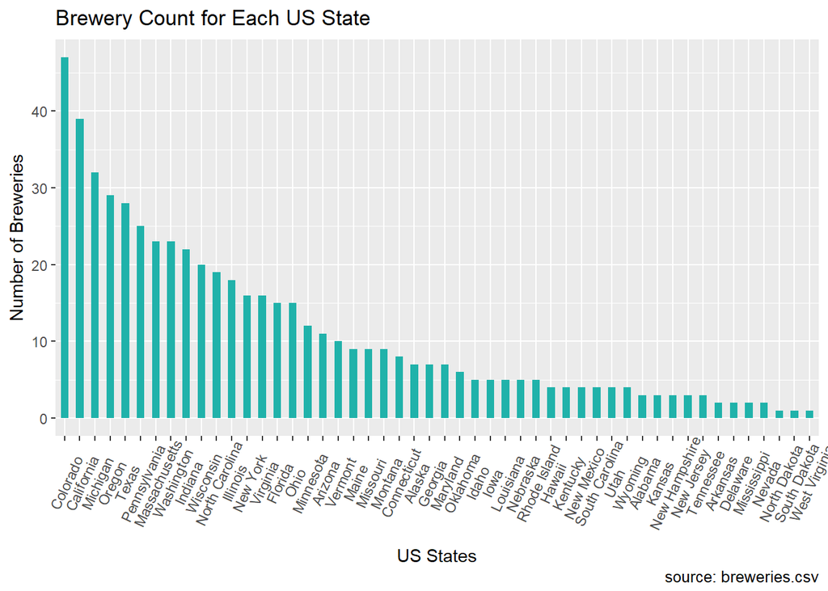

```r
# Plot the brewery list by state in a barchart in descending order by brewery count.
# Note:  even though the sortdescbybrewcount dataframe is already in descending order, ggplot
# must still be told the specific sort to use;  this is achieved with "reorder" segment
ggplot(sortdescbybrewcount,aes(x=reorder(State_Name,-Brewery_Count), y=Brewery_Count)) +
          geom_bar(stat="identity", width=.5, fill="lightseagreen") +
          labs(title="Brewery Count for Each US State",
               caption="source: breweries.csv") +
          theme(axis.text.x = element_text(angle=65, vjust=0.6)) + ylab("Number of Breweries")+ xlab("US States")
```

## Characteristics: ABV and IBU

Comparing the ABV and IBU characteristics of De Halve Maan’s product line to that of beers in prospective US markets will help narrow down potential clientele who may have a higher likelihood of trying the new international products because doing so would not be a drastic change from their usual drink of choice.

## ABV

The mean and median ABV for De Halve Maan’s product line are both approximately 8%, while that of the US breweries are both approximately 6%. While 33% greater median alcohol content is one factor that could work toward setting the De Halve Maan product line apart from US competitors, verification of the maximum legal alcohol content limit for import and resale is necessary with respect to each US state as well. Please reference bar chart below showing Median ABV by US State. Note that the De Halve Maan’s product line well exceeds the US breweries’ maximum median by state of approximately 6.3%.

```r
#get the statistical summary for the ABV metric from the final merged dataset
beer.stats.abv <- summary(beer.breweries.state.clean$ABV)
beer.stats.abv
```

```
##    Min. 1st Qu.  Median    Mean 3rd Qu.    Max.    NA's
## 0.00100 0.05000 0.05600 0.05977 0.06700 0.12800      62
```

```r
# median of ABV per state
beer.stateABV <- aggregate( ABV ~ State_Name, data=beer.breweries.state , median)
# convert ABV value to percent
beer.stateABV$ABV_per <- beer.stateABV$ABV * 100

# rename field names for beer.stateABV
names(beer.stateABV) <- c("State_Name","Median_ABV","Median_ABV_Percentage")

# display first few records for beer.stateABV
head(beer.stateABV)
```

```
##   State_Name Median_ABV Median_ABV_Percentage
## 1    Alabama     0.0600                  6.00
## 2     Alaska     0.0560                  5.60
## 3    Arizona     0.0550                  5.50
## 4   Arkansas     0.0520                  5.20
## 5 California     0.0580                  5.80
## 6   Colorado     0.0605                  6.05
```

## IBU

An individual beer’s IBU contributes to its unique taste and depth. Although there may be more competition in areas that sell similar IBU levels, this may reflect the population at large being attracted to that specific quality of beer. Based on the below chart showing Median IBU by US State, De Halve Maan’s median IBU of 32.5 falls approximately in the middle of the US breweries.

```r
# median of IBU per state
beer.stateIBU <- aggregate( IBU ~ State_Name, data=beer.breweries.state , median)
# rename field names for beer.stateIBU
names(beer.stateIBU) <- c("State_Name","Median_IBU")

# display first few records for beer.stateIBU
head(beer.stateIBU)
```

```
##   State_Name Median_IBU
## 1    Alabama       43.0
## 2     Alaska       46.0
## 3    Arizona       20.5
## 4   Arkansas       39.0
## 5 California       42.0
## 6   Colorado       40.0
```

## Plots: Median ABV by State and Median IBU by State

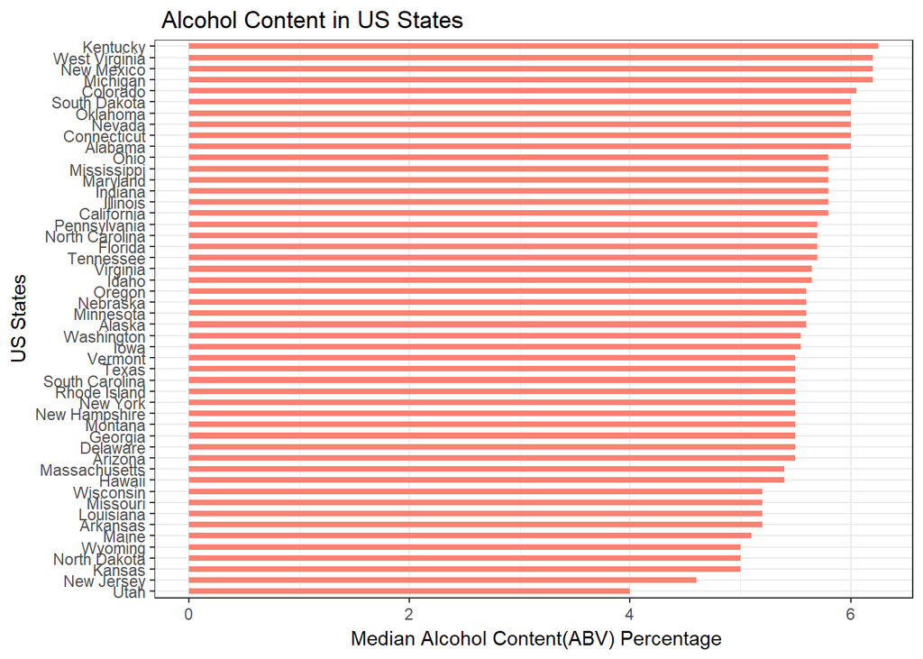

```r
# barplot that maps median of ABV percentage per state

ggplot(beer.stateABV, aes(reorder(State_Name,Median_ABV_Percentage),Median_ABV_Percentage)) + geom_bar(stat="identity" , fill = "salmon" ,width = 0.5)  + coord_flip()  + theme_bw() + ggtitle(" Alcohol Content in US States") + ylab(" Median Alcohol Content(ABV) Percentage")   + xlab("US States")
```

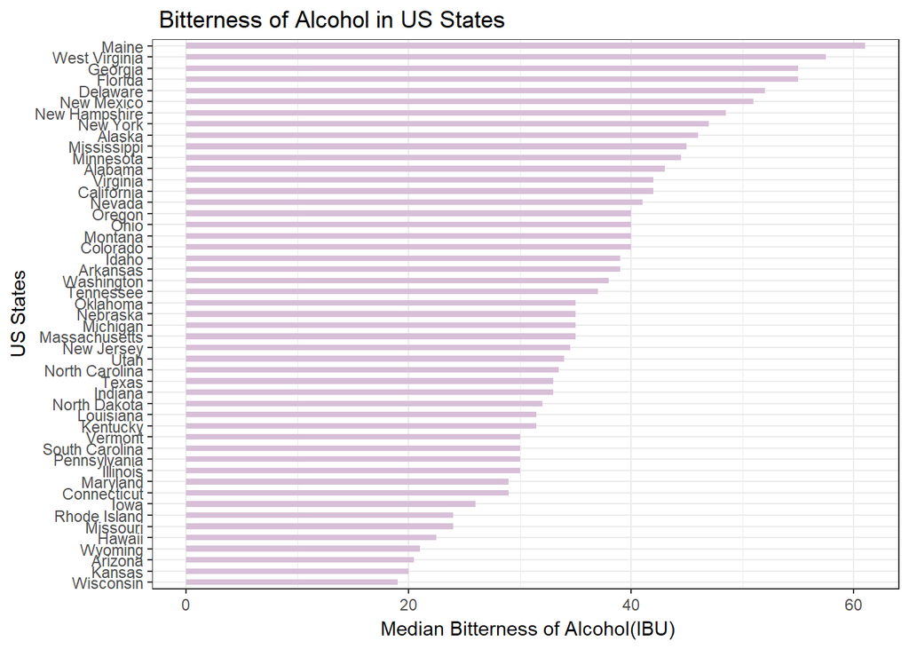

```r
# barplot that maps median of IBU per state

ggplot(beer.stateIBU, aes(reorder(State_Name,Median_IBU),Median_IBU)) + geom_bar(stat="identity" , fill = "thistle" ,width = 0.5)  + coord_flip()  + theme_bw() + ggtitle(" Bitterness of Alcohol in US States") + ylab(" Median Bitterness of Alcohol(IBU)")   + xlab("US States")
```

## States with maximum ABV and IBU

While Colorado has the maximum ABV of 12.8%, exceeding that of De Halve Maan’s, it may be due local, within-state micro-brewing allowing for higher ABV, than would apply to other beers, such as out-of-state and imports. Since Oregon has the maximum IBU of 138, far exceeding De Halve Maan’s, there is no concern that the imported Belgian beer would be too extreme than other available options.

```r
# sort beer.brweries.state.cean dataset in decreasing order of ABV
beer.stateABV.sorted <- beer.breweries.state.clean[order(-beer.breweries.state.clean$ABV),]

# State with highest  value of ABV
beer.stateABV.sorted[1,c("Brewery_State","ABV")]
```

```
##     Brewery_State   ABV
## 375            CO 0.128
```

```r
# sort beer.brweries.state.cean dataset in decreasing order of IBU
beer.stateIBU.sorted <- beer.breweries.state.clean[order(-beer.breweries.state.clean$IBU),]

# State with highest  value of IBU
beer.stateIBU.sorted[1,c("Brewery_State","IBU")]
```

```
##      Brewery_State IBU
## 1857            OR 138
```

## Scatterplot of IBU vs ABV% for US Breweries, with De Halve Maan Median Reference Point

```r
# Scatterplot of IBU vs ABV Percent, with Customer Median Reference Point (red), and a linar model and confidence interval

IBU.ABV.relation <- ggplot(beer.breweries.state.clean, aes(beer.breweries.state.clean$ABV, beer.breweries.state.clean$IBU)) +
  geom_point(shape=18, color="maroon4")+
  geom_point(aes(x= .0825, y = 32.5), color="darkblue", size = 5)+
  geom_smooth(method=lm,  linetype="dashed", color="forestgreen", fill="darkblue") +
  scale_color_gradient() +
  theme_bw() +
  scale_x_continuous(labels = percent) +
  ggtitle("US IBU vs ABV%, with Customer Median Reference point (dark blue)") + ylab("Bitterness of Beer(IBU)") + xlab("Alcohol Content Percent (ABV%)")
```

[output not shown]

# Conclusion and Recommendations

Given that the analysis was only able to use the relatively small sample of IBU data available, decisions based on this information should be made with discretion. In general, based on the above observations, if De Halve Maan decides to expand their overseas market into the United States, consumers would mostly likely welcome it, as the characteristics of the beers do not seem to deviate from the typical range of choices currently available in the United States.

Recommendations for phase two of the analysis, include investigating US regional characteristics and seasonal considerations. Introducing the product line to a region instead of individual states in various parts of the country could be a more cost effective approach. In addition, coordinating promotional events in conjuction with regional introduction would enable the De Halve Maan sales team to focus on targeted efforts and minimize travel costs. On a single transatlantic trip the team could visit multiple locations for special events such as the US Oktoberfests held from late August through October.

The team looks forward to working with De Halve Maan on future analysis. Thank you.